# Logistic Regression with PCA Example

Dr. Clifton Baldwin

April 2020

This script reads in breast cancer data, does a PCA to determine significant features, and then does some logistic regressions using the significant features from the first few principal components

```r
library(tidyverse) # For read_csv and ggplot
library(factoextra) # For fviz_screeplot and fviz_contrib
```

Cancer data

- https://archive.ics.uci.edu/ml/datasets/Breast+Cancer+Wisconsin+(Diagnostic)
- https://towardsdatascience.com/dive-into-pca-principal-component-analysis-with-python-43ded13ead21
- http://jotterbach.github.io/2016/03/24/Principal_Component_Analysis/

I want to determine Diagnosis, which requires supervised learning, but I do not know what features to include in my model. I need to determine what columns in the dataset are appropriate for analysis, for example, I want to identify possible data from identifiers like IDs or Names. Then I can use PCA to determine the features for a logistic regression supervised learning model. I will compute the principal components. Then I will select a subset of original features from the weights of the principal components. Using the original variables and then again with the principal components, I will run a logistic regression. Finally I will look at the statistics to see how good each model does.

Prep the data using “cleaned data”

```r
cancer <- read_csv("wdbc.csv", col_names = TRUE)
# Let us see the data
glimpse(cancer)
```

```
Observations: 569
Variables: 32
$ ID                      <dbl> 842302, 842517, 84300903, 84348301, 84358402, 843786, 844…
$ Diagnosis               <chr> "M", "M", "M", "M", "M", "M", "M", "M", "M", "M", "M", "M…
$ mean_radius             <dbl> 17.990, 20.570, 19.690, 11.420, 20.290, 12.450, 18.250, 1…
$ mean_texture            <dbl> 10.38, 17.77, 21.25, 20.38, 14.34, 15.70, 19.98, 20.83, 2…
$ mean_perimeter          <dbl> 122.80, 132.90, 130.00, 77.58, 135.10, 82.57, 119.60, 90.…
$ mean_area               <dbl> 1001.0, 1326.0, 1203.0, 386.1, 1297.0, 477.1, 1040.0, 577…
$ mean_smoothness         <dbl> 0.11840, 0.08474, 0.10960, 0.14250, 0.10030, 0.12780, 0.0…
$ mean_compactness        <dbl> 0.27760, 0.07864, 0.15990, 0.28390, 0.13280, 0.17000, 0.1…
$ mean_concavity          <dbl> 0.30010, 0.08690, 0.19740, 0.24140, 0.19800, 0.15780, 0.1…
$ mean_concave_points     <dbl> 0.14710, 0.07017, 0.12790, 0.10520, 0.10430, 0.08089, 0.0…
$ mean_symmetry           <dbl> 0.2419, 0.1812, 0.2069, 0.2597, 0.1809, 0.2087, 0.1794, 0…
$ mean_fractal_dimension  <dbl> 0.07871, 0.05667, 0.05999, 0.09744, 0.05883, 0.07613, 0.0…
$ se_radius               <dbl> 1.0950, 0.5435, 0.7456, 0.4956, 0.7572, 0.3345, 0.4467, 0…
```

[output cut: 19 more lines]

Notice that Diagnosis is a character with either B (benign) or M (malignant). Since there is a finite (only 2) choices for this feature, I will convert it to a factor

```r
cancer$Diagnosis <- factor(cancer$Diagnosis)
```

Also note that the first column is ID. I do not think it will be useful in any analysis. I will use the remaining columns as features in a PCA.

```r
pcaCancer <- prcomp(cancer[3:32], center = TRUE, scale. = TRUE)
```

Proportion of variance explained for 1st principal component

```r
vars <- pcaCancer$rotation[,1] / sum(pcaCancer$rotation[,1])
head(vars[order(-vars)])
```

```
 mean_concave_points       mean_concavity worst_concave_points     mean_compactness
          0.05169734           0.05121114           0.04972187           0.04742280
     worst_perimeter      worst_concavity
          0.04689847           0.04533833
```

mean_concave_points is the strongest (not by much) contributor.

Proportion of variance explained for 2nd principal component

```r
vars <- pcaCancer$rotation[,2] / sum(pcaCancer$rotation[,2])
head(vars[order(-vars)])
```

```
 mean_fractal_dimension    se_fractal_dimension worst_fractal_dimension
              0.2841535               0.2171152               0.2134313
         se_compactness           se_smoothness            se_concavity
              0.1803913               0.1584657               0.1528666
```

mean_fractal_dimension is the strongest contributor.

Proportion of variance explained for 3rd principal component

```r
vars <- pcaCancer$rotation[,3] / sum(pcaCancer$rotation[,3])
head(vars[order(-vars)])
```

```
       se_texture     se_smoothness       se_symmetry         se_radius      se_perimeter
        0.4634608         0.3820659         0.3570088         0.3321394         0.3298680
se_concave_points
        0.2779248
```

se_texture

Proportion of variance explained for 4th principal component

```r
vars <- pcaCancer$rotation[,4] / sum(pcaCancer$rotation[,4])
head(vars[order(-vars)])
```

```
          worst_texture            mean_texture              se_texture
             0.77147824              0.73519936              0.43871247
      worst_compactness worst_fractal_dimension         worst_concavity
             0.11134167              0.09393858              0.09015647
```

worst_texture

We could graph the contributions to each principal component

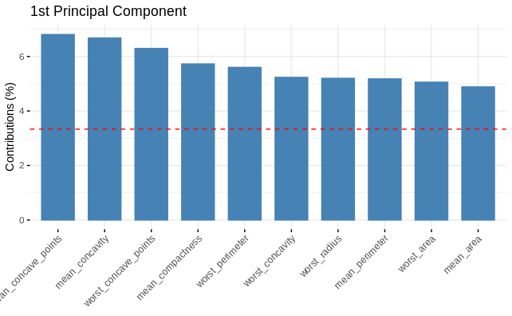

```r
fviz_contrib(pcaCancer, choice = "var", sort.val = c("desc"), axes = 1, top = 10, title = "1st Principal Component")
```

It does not appear that there is a clear winner?? Maybe we will have to use the principal components instead of the contributing variables?

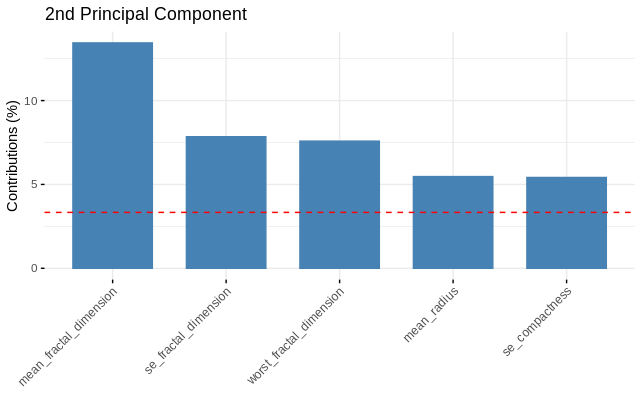

```r
fviz_contrib(pcaCancer, choice = "var", sort.val = c("desc"), axes = 2, top = 5, title = "2nd Principal Component")
```

mean_fractal_dimension is clearly the strongest contributor

I can get these four columns in this case using cancer[,c(10,12,14,24)] (I had to figure that out by looking at names(cancer))

```r
names(cancer[,c(10,12,14,24)])
```

```
[1] "mean_concave_points"    "mean_fractal_dimension" "se_texture"
[4] "worst_texture"
```

I want to make sure se_texture and worst_texture are NOT correlated.

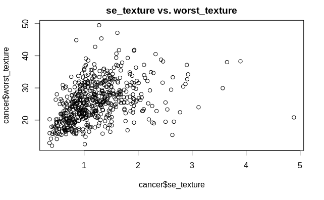

```r
plot(cancer$se_texture, cancer$worst_texture, main = "se_texture vs. worst_texture")
```

Or using ggplot so I can add a regression line

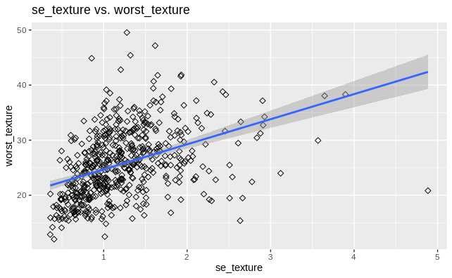

```r
ggplot(cancer, aes(x=se_texture, y=worst_texture)) +
  geom_point(size=2, shape=23) +
  geom_smooth(method='lm') +
  labs(title="se_texture vs. worst_texture")
```

```r
cor(cancer$se_texture, cancer$worst_texture)
```

```
[1] 0.4090028
```

Hmm, those two features might be weakly correlated, but I will keep them anyway. However, I have to keep in mind they may be correlated, in which case I may end up not using both.

Let us separate training and test data.

```r
set.seed(23)
indexes <- sample(1:nrow(cancer), size=0.75*nrow(cancer))
training <- cancer[indexes,]
testing <- cancer[-indexes,]
rm(indexes)
```

Now run a logistic regression using the four determined features.

```r
diagnose = glm(Diagnosis ~ mean_concave_points + mean_fractal_dimension + se_texture + worst_texture, data=training, family=binomial)
```

Look at the results of the logistic regression.

```r
summary(diagnose)
```

```
Call:
glm(formula = Diagnosis ~ mean_concave_points + mean_fractal_dimension +
    se_texture + worst_texture, family = binomial, data = training)

Deviance Residuals:
    Min       1Q   Median       3Q      Max
-1.9869  -0.1365  -0.0258   0.0372   3.3857

Coefficients:
                         Estimate Std. Error z value Pr(>|z|)
(Intercept)              -4.97074    2.79201  -1.780 0.075019 .
mean_concave_points     150.02211   19.76962   7.589 3.24e-14 ***
mean_fractal_dimension -162.51587   45.33638  -3.585 0.000338 ***
se_texture               -2.09973    0.71709  -2.928 0.003410 **
worst_texture             0.36795    0.06359   5.786 7.19e-09 ***
---
Signif. codes:  0 ‘***’ 0.001 ‘**’ 0.01 ‘*’ 0.05 ‘.’ 0.1 ‘ ’ 1

(Dispersion parameter for binomial family taken to be 1)

    Null deviance: 564.91  on 425  degrees of freedom
Residual deviance: 102.04  on 421  degrees of freedom
AIC: 112.04

Number of Fisher Scoring iterations: 8
```

Using the training data, let us look at the confusion matrix. I will use 0.45 instead of 0.5 as the boundary because I want to err on the side of catching a cancer.

```r
predictTrain = predict(diagnose, type="response")
table(training$Diagnosis, predictTrain >= 0.45)
```

```
    FALSE TRUE
  B   256    9
  M    12  149
```

The sensitivity

```r
t1 = table(training$Diagnosis, predictTrain >= 0.45)
t1[4]/(t1[2] + t1[4]) # sensitivity
```

```
[1] 0.9254658
```

And the specificity

```r
t1[1]/(t1[1] + t1[3]) # specificity
```

```
[1] 0.9660377
```

And the accuracy

```r
(t1[1] + t1[4])/(t1[1] + t1[2] + t1[3] + t1[4]) # accuracy
```

```
[1] 0.9507042
```

Really good! But that was using the training data. I really need to get the confusion matrix using the testing data.

```r
predictTest = predict(diagnose, type="response", newdata=testing)
table(testing$Diagnosis, predictTest >= 0.45)
```

```
    FALSE TRUE
  B    88    4
  M     4   47
```

The metrics are

```r
t1 = table(testing$Diagnosis, predictTest >= 0.45)
t1[4]/(t1[2] + t1[4]) # sensitivity
```

```
[1] 0.9215686
```

```r
t1[1]/(t1[1] + t1[3]) # specificity
```

```
[1] 0.9565217
```

And the accuracy is

```r
(t1[1] + t1[4])/(t1[1] + t1[2] + t1[3] + t1[4]) # accuracy
```

```
[1] 0.9440559
```

94% That is really good

Maybe we can do even better without our possible correlation.

```r
diagnose = glm(Diagnosis ~ mean_concave_points + mean_fractal_dimension + se_texture, data=training, family=binomial)
predictTest = predict(diagnose, type="response", newdata=testing)
```

The accuracy is computed as follows:

```r
t1 = table(testing$Diagnosis, predictTest >= 0.45)
(t1[1] + t1[4])/(t1[1] + t1[2] + t1[3] + t1[4]) # accuracy
```

```
[1] 0.8951049
```

```r
rm(t1)
```

A bit worse, but maybe different features again

```r
diagnose = glm(Diagnosis ~ mean_concave_points + mean_fractal_dimension + worst_texture, data=training, family=binomial)
predictTest = predict(diagnose, type="response", newdata=testing)
t1 = table(testing$Diagnosis, predictTest >= 0.45)
(t1[1] + t1[4])/(t1[1] + t1[2] + t1[3] + t1[4]) # accuracy
```

```
[1] 0.9440559
```

```r
rm(t1)
```

Now let us try again but this time with the principal components. Create a graph to determine how many principal components I should use.

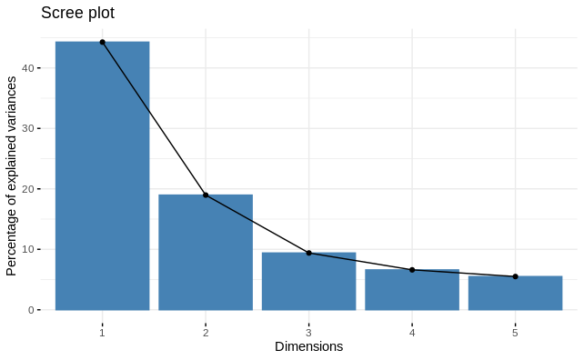

```r
fviz_screeplot(pcaCancer, ncp=5)
```

Looks like two or maybe three principal components would be enough.

Again, I need training and test data

```r
set.seed(23)
indexes <- sample(1:nrow(cancer), size=0.75*nrow(cancer))

# Because we are using the principal components, from pcaCancer, we need to include the target variable
Diagnosis <- cancer[indexes,]$Diagnosis
training <- data.frame(Diagnosis, pcaCancer$x[indexes,] )

Diagnosis <- cancer[-indexes,]$Diagnosis
testing <- data.frame(Diagnosis, pcaCancer$x[-indexes,] )
rm(Diagnosis)
```

Now run the logistic regression using the first three principal components

```r
diagnose = glm(Diagnosis ~ PC1 + PC2 + PC3, data = training, family=binomial)
predictTest = predict(diagnose, type="response", newdata=testing)
t1 = table(testing$Diagnosis, predictTest >= 0.45)
(t1[1] + t1[4])/(t1[1] + t1[2] + t1[3] + t1[4]) # accuracy
```

```
[1] 0.9440559
```

```r
rm(t1)
```

Maybe we can do better with only two principal components

```r
diagnose = glm(Diagnosis ~ PC1 + PC2, data = training, family=binomial)
predictTest = predict(diagnose, type="response", newdata=testing)
t1 = table(testing$Diagnosis, predictTest >= 0.45)
(t1[1] + t1[4])/(t1[1] + t1[2] + t1[3] + t1[4]) # accuracy
```

```
[1] 0.9440559
```

```r
rm(t1)
```

WOW! 94% accuracy - with only two principal components!

I suspect that the lack of a clear contributor to the 1st principal component should have convinced us to use the principal components anyway.